# ewar213_Assignment2

```python
import os
print(os.getcwd())
```

```
C:\Users\Elliot\Documents\Uni\2020\ES712\assignment2
```

```python
# Task 2
# Assume csv file is in same folder as the notebook
# The csv file contains 129 seconds of running at 12 km/h, recorded at the right hand.
import pandas as pd
runDf = pd.read_csv('running.csv',
                 parse_dates=True,
                 skiprows=0,
                 index_col='time',
                 header=0,
                 names=['time','ax','ay','az','|a|'])
runDf.head()
```

| time | ax | ay | az | \|a\| |
| --- | --- | --- | --- | --- |
| 18:26:09:4730 | 3.4085 | -3.3649 | 3.8253 | 6.130 |
| 18:26:09:4810 | 2.4265 | -3.3442 | 5.1118 | 6.573 |
| 18:26:09:4940 | 3.0948 | -3.5465 | 6.9652 | 8.406 |
| 18:26:09:5000 | 4.0363 | -3.1975 | 7.3483 | 8.973 |
| 18:26:09:5140 | 3.8738 | -2.6536 | 5.3303 | 7.104 |

```python
# Convert to datetime
runDf.index = pd.to_datetime(runDf.index, format='%H:%M:%S:%f')
```

```python
runDf.index
```

```
DatetimeIndex(['1900-01-01 18:26:09.473000', '1900-01-01 18:26:09.481000',
               '1900-01-01 18:26:09.494000', '1900-01-01 18:26:09.500000',
               '1900-01-01 18:26:09.514000', '1900-01-01 18:26:09.520000',
               '1900-01-01 18:26:09.534000', '1900-01-01 18:26:09.540000',
               '1900-01-01 18:26:09.551000', '1900-01-01 18:26:09.560000',
               ...
               '1900-01-01 18:28:18.464000', '1900-01-01 18:28:18.484000',
               '1900-01-01 18:28:18.485000', '1900-01-01 18:28:18.501000',
               '1900-01-01 18:28:18.502000', '1900-01-01 18:28:18.513000',
               '1900-01-01 18:28:18.522000', '1900-01-01 18:28:18.534000',
               '1900-01-01 18:28:18.543000', '1900-01-01 18:28:18.554000'],
              dtype='datetime64[ns]', name='time', length=12909, freq=None)
```

```python
# The csv file contains 151 seconds of walking at 5 km/h, recorded at the right hand.
import pandas as pd
walkDf = pd.read_csv('walking.csv',
                 parse_dates=True,
                 skiprows=0,
                 index_col='time',
                 header=0,
                 names=['time','ax','ay','az','|a|'])
walkDf.index = pd.to_datetime(walkDf.index, format='%H:%M:%S:%f')
walkDf.head()
```

| time | ax | ay | az | \|a\| |
| --- | --- | --- | --- | --- |
| 1900-01-01 18:23:13.695900 | 1.1436 | -1.0226 | -0.7785 | 1.720 |
| 1900-01-01 18:23:13.700000 | 1.6888 | -1.5026 | -2.3084 | 3.231 |
| 1900-01-01 18:23:13.708000 | 2.0050 | -1.8894 | -3.4790 | 4.438 |
| 1900-01-01 18:23:13.721000 | 2.1915 | -2.4522 | -5.2894 | 6.228 |
| 1900-01-01 18:23:13.727000 | 2.2746 | -2.9228 | -5.9337 | 6.995 |

```python
# Task 3
# The device was supposed to record at 100Hz. Visualising the first and last 3000 samples should give us around 30s of data.
# This will easily allow us to see the transitions at the start and end of recording
%matplotlib inline
import numpy as np
import matplotlib.pyplot as plt

def visualiseData(dataset, activity):
    timeInSeconds = dataset.index - dataset.index[0]

    timeScale = timeInSeconds[0:3000].seconds + timeInSeconds[0:3000].microseconds/1000000 # observe the start of series
    data1 = dataset['|a|'].iloc[0:3000]

    timeScale2 = timeInSeconds[-3000:-1].seconds + timeInSeconds[-3000:-1].microseconds/1000000 # "     "  end of series
    data4 = dataset['|a|'].iloc[-3000:-1]

    fig, axs = plt.subplots(1, 2, figsize=(20,7))
    fig.suptitle('Beginning and end of signal ('+activity+')', y=1.02, fontsize='xx-large')
    axs[0].plot(timeScale, data1)
    axs[0].set_title('|a| start', fontsize='x-large')
    axs[0].set_xlabel('Time (s)', fontsize='x-large')
    axs[0].set_ylabel('Acceleration (m/s^2)', fontsize='x-large')

    axs[1].plot(timeScale2, data4)
    axs[1].set_title('|a| end', fontsize='x-large')
    axs[1].set_xlabel('Time (s)', fontsize='x-large')

    fig.tight_layout(pad=1.0)
    # Repeated axes labels (i.e. acceleration) have been removed to improve readability
```

```python
import matplotlib
matplotlib.get_backend()
```

```
'module://ipykernel.pylab.backend_inline'
```

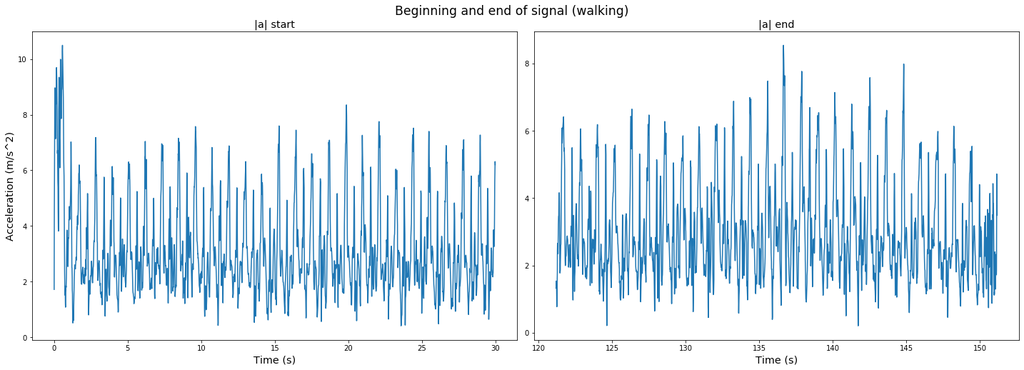

```python
visualiseData(walkDf, 'walking')
```

There appears to be a transition period of around 3 seconds at the start and end of the signal  
The range of acceleration is about (0, 8) m/s^2.

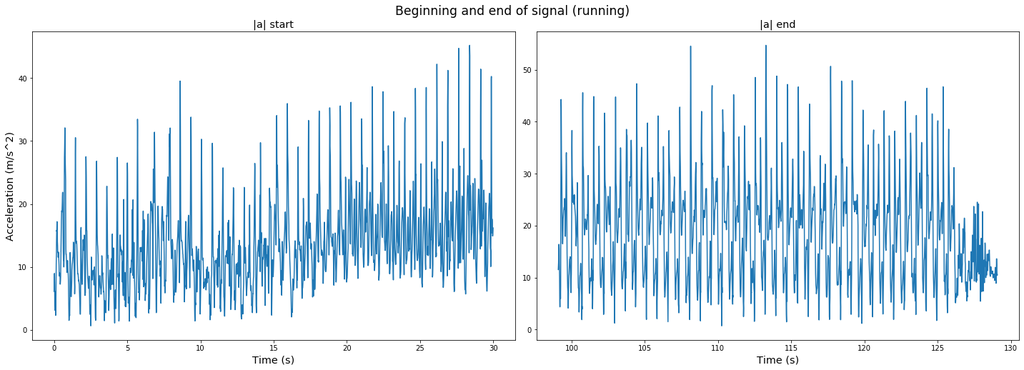

```python
visualiseData(runDf, 'running')
```

There appears to be a transition period of around 3 seconds at the start and 5 seconds at the end of the signal.  
The range of acceleration is about (0, 50) m/s^2 respectively.  
This is quite a lot higher than the walking signals, which is to be expected.  
Each cycle is also a lot shorter, but it is difficult to quantify the change in period from these plots alone.

```python
# Task 4
# Remove the first and last 3 seconds of each signal to remove the transition periods
import datetime

startTime = walkDf.index[0] + pd.DateOffset(seconds=3)
endTime = walkDf.index[-1] + pd.DateOffset(seconds=-3)
walkDf = walkDf[(walkDf.index > startTime) & (walkDf.index < endTime)]
walkDf.head()

# Remove the last 10 seconds for running
startTime = runDf.index[0] + pd.DateOffset(seconds=3)
endTime = runDf.index[-1] + pd.DateOffset(seconds=-5)
runDf = runDf[(runDf.index > startTime) & (runDf.index < endTime)]

walkDf['delta_t'] = (walkDf.index - walkDf.index[0]).fillna(0)
runDf['delta_t'] = (runDf.index - runDf.index[0]).fillna(0)
# note that the change in time is varying
```

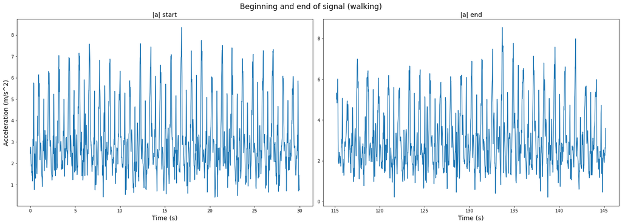

```python
# Visualising the data after pruning
visualiseData(walkDf, 'walking')
```

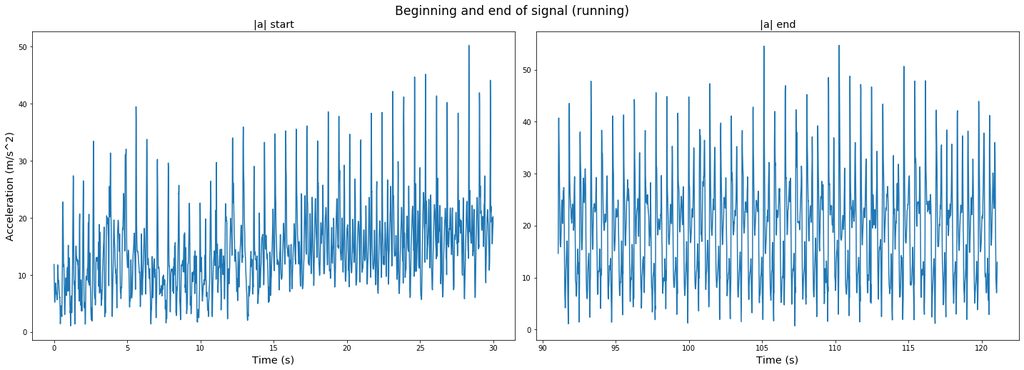

```python
visualiseData(runDf, 'running')
```

```python
print('walking dataset duration = ' + str(walkDf.index[-1] - walkDf.index[0]))
print('running dataset duration = ' + str(runDf.index[-1] - runDf.index[0]))
print('number of walking dataset samples = ' + str(len(walkDf)) )
print('number of running dataset samples = ' + str(len(runDf)) )
```

```
walking dataset duration = 0 days 00:02:25.167000
running dataset duration = 0 days 00:02:01.059000
number of walking dataset samples = 14518
number of running dataset samples = 12107
```

```python
# Task 5
# remove incomplete time period
incompleteWindow = len(walkDf)%100
walkDf = walkDf.iloc[:-incompleteWindow]
walkDf2 = walkDf.reset_index()
idx = np.asarray(np.floor(walkDf2.index/100).values, np.int)
walkDf['window_idx'] = ['w{:03}'.format(i) for i in idx]
walkDf
```

| time | ax | ay | az | \|a\| | delta_t | window_idx |
| --- | --- | --- | --- | --- | --- | --- |
| 1900-01-01 18:23:16.699 | 0.6022 | 2.2662 | 0.7395 | 2.459 | 00:00:00 | w000 |
| 1900-01-01 18:23:16.707 | 0.4814 | 2.3803 | 0.8244 | 2.565 | 00:00:00.008000 | w000 |
| 1900-01-01 18:23:16.718 | 0.0959 | 2.5000 | 0.9454 | 2.675 | 00:00:00.019000 | w000 |
| 1900-01-01 18:23:16.734 | -0.2177 | 2.5082 | 0.9753 | 2.700 | 00:00:00.035000 | w000 |
| 1900-01-01 18:23:16.739 | -0.6916 | 2.4904 | 0.9592 | 2.757 | 00:00:00.040000 | w000 |
| ... | ... | ... | ... | ... | ... | ... |
| 1900-01-01 18:25:41.642 | -1.5431 | 1.5757 | 0.5043 | 2.262 | 00:02:24.943000 | w144 |
| 1900-01-01 18:25:41.658 | -1.3607 | 1.5628 | 0.5510 | 2.144 | 00:02:24.959000 | w144 |
| 1900-01-01 18:25:41.666 | -1.1875 | 1.6194 | 0.5446 | 2.081 | 00:02:24.967000 | w144 |
| 1900-01-01 18:25:41.676 | -0.8655 | 1.7117 | 0.5438 | 1.994 | 00:02:24.977000 | w144 |
| 1900-01-01 18:25:41.682 | -0.7880 | 1.7118 | 0.5387 | 1.960 | 00:02:24.983000 | w144 |

14500 rows × 6 columns

```python
# remove incomplete time period

incompleteWindow = len(runDf)%100
runDf = runDf.iloc[:-7]
runDf2 = runDf.reset_index()
idx = np.asarray(np.floor(runDf2.index/100).values, np.int)
runDf['window_idx'] = ['r{:03}'.format(i) for i in idx]
runDf
```

| time | ax | ay | az | \|a\| | delta_t | window_idx |
| --- | --- | --- | --- | --- | --- | --- |
| 1900-01-01 18:26:12.481 | -1.0171 | 11.4619 | 2.8902 | 11.864 | 00:00:00 | r000 |
| 1900-01-01 18:26:12.492 | -1.5465 | 10.0454 | 1.9522 | 10.350 | 00:00:00.011000 | r000 |
| 1900-01-01 18:26:12.501 | -2.0037 | 8.1344 | 1.4007 | 8.494 | 00:00:00.020000 | r000 |
| 1900-01-01 18:26:12.513 | -2.9404 | 5.8229 | 1.2361 | 6.639 | 00:00:00.032000 | r000 |
| 1900-01-01 18:26:12.522 | -3.9464 | 3.3474 | 0.9641 | 5.264 | 00:00:00.041000 | r000 |
| ... | ... | ... | ... | ... | ... | ... |
| 1900-01-01 18:28:13.440 | 9.8799 | 6.2458 | 5.6632 | 12.988 | 00:02:00.959000 | r120 |
| 1900-01-01 18:28:13.441 | 6.5429 | 4.5570 | 6.0298 | 9.997 | 00:02:00.960000 | r120 |
| 1900-01-01 18:28:13.465 | 3.7659 | 2.9697 | 6.8177 | 8.336 | 00:02:00.984000 | r120 |
| 1900-01-01 18:28:13.465 | 1.8715 | 1.1993 | 7.5586 | 7.879 | 00:02:00.984000 | r120 |
| 1900-01-01 18:28:13.482 | 0.2904 | -0.7106 | 7.5880 | 7.627 | 00:02:01.001000 | r120 |

12100 rows × 6 columns

```python
df = pd.concat([walkDf, runDf], ignore_index=False)
df
```

| time | ax | ay | az | \|a\| | delta_t | window_idx |
| --- | --- | --- | --- | --- | --- | --- |
| 1900-01-01 18:23:16.699 | 0.6022 | 2.2662 | 0.7395 | 2.459 | 00:00:00 | w000 |
| 1900-01-01 18:23:16.707 | 0.4814 | 2.3803 | 0.8244 | 2.565 | 00:00:00.008000 | w000 |
| 1900-01-01 18:23:16.718 | 0.0959 | 2.5000 | 0.9454 | 2.675 | 00:00:00.019000 | w000 |
| 1900-01-01 18:23:16.734 | -0.2177 | 2.5082 | 0.9753 | 2.700 | 00:00:00.035000 | w000 |
| 1900-01-01 18:23:16.739 | -0.6916 | 2.4904 | 0.9592 | 2.757 | 00:00:00.040000 | w000 |
| ... | ... | ... | ... | ... | ... | ... |
| 1900-01-01 18:28:13.440 | 9.8799 | 6.2458 | 5.6632 | 12.988 | 00:02:00.959000 | r120 |
| 1900-01-01 18:28:13.441 | 6.5429 | 4.5570 | 6.0298 | 9.997 | 00:02:00.960000 | r120 |
| 1900-01-01 18:28:13.465 | 3.7659 | 2.9697 | 6.8177 | 8.336 | 00:02:00.984000 | r120 |
| 1900-01-01 18:28:13.465 | 1.8715 | 1.1993 | 7.5586 | 7.879 | 00:02:00.984000 | r120 |
| 1900-01-01 18:28:13.482 | 0.2904 | -0.7106 | 7.5880 | 7.627 | 00:02:01.001000 | r120 |

26600 rows × 6 columns

```python
print('There are ' + str(df.shape[0]/100) + ' unique windows')
```

```
There are 266.0 unique windows
```

```python
#timeInSeconds = df.index - df.index[0]
#seconds = timeInSeconds.seconds + timeInSeconds.microseconds/1000000 # convert the timedeltas to float64
#df['delta_t'] = seconds
df.dtypes
```

```
ax                    float64
ay                    float64
az                    float64
|a|                   float64
delta_t       timedelta64[ns]
window_idx             object
dtype: object
```

```python
from tsfresh.feature_extraction.settings import ComprehensiveFCParameters
fc_parameters = ComprehensiveFCParameters()
```

```python
from tsfresh.feature_extraction import extract_features

X = extract_features(df,
                     column_id='window_idx',
                     column_sort='delta_t',
                    default_fc_parameters = fc_parameters
                    )
```

```python
# save the original feature matrix for debugging
saveX = X
```

```python
print('The dimensions of the feature matrix are ' + str(X.shape))
print('There are ' + str(X.shape[1]) + ' unique features')
```

```
The dimensions of the feature matrix are (266, 3036)
There are 3036 unique features
```

```python
# remove invalid features
X = X.dropna(axis=1)
X
```

| variable id | ax__abs_energy | ax__absolute_sum_of_changes | ax__agg_autocorrelation__f_agg_"mean"__maxlag_40 | ax__agg_autocorrelation__f_agg_"median"__maxlag_40 | ax__agg_autocorrelation__f_agg_"var"__maxlag_40 | ax__agg_linear_trend__f_agg_"max"__chunk_len_10__attr_"intercept" | ax__agg_linear_trend__f_agg_"max"__chunk_len_10__attr_"rvalue" | ax__agg_linear_trend__f_agg_"max"__chunk_len_10__attr_"slope" | ax__agg_linear_trend__f_agg_"max"__chunk_len_10__attr_"stderr" | ax__agg_linear_trend__f_agg_"max"__chunk_len_50__attr_"intercept" | ... | \|a\|__symmetry_looking__r_0.9 | \|a\|__symmetry_looking__r_0.9500000000000001 | \|a\|__time_reversal_asymmetry_statistic__lag_1 | \|a\|__time_reversal_asymmetry_statistic__lag_2 | \|a\|__time_reversal_asymmetry_statistic__lag_3 | \|a\|__value_count__value_-1 | \|a\|__value_count__value_0 | \|a\|__value_count__value_1 | \|a\|__variance | \|a\|__variance_larger_than_standard_deviation |
| --- | --- | --- | --- | --- | --- | --- | --- | --- | --- | --- | --- | --- | --- | --- | --- | --- | --- | --- | --- | --- | --- |
| r000 | 2941.144718 | 131.0726 | 0.046818 | -0.006856 | 0.131489 | 2.789158 | 0.317215 | 0.723812 | 0.765062 | 11.2978 | ... | 1.0 | 1.0 | -8.705091 | 13.580936 | 5.640982 | 0.0 | 0.0 | 0.0 | 16.815275 | 1.0 |
| r001 | 4360.162170 | 171.3270 | -0.010411 | -0.016224 | 0.131164 | 7.789673 | 0.052925 | 0.125866 | 0.839637 | 17.4586 | ... | 1.0 | 1.0 | 151.623195 | 216.909257 | 184.779993 | 0.0 | 0.0 | 0.0 | 32.933673 | 1.0 |
| r002 | 4571.948624 | 188.9882 | -0.011806 | -0.024136 | 0.066076 | 10.439764 | -0.104348 | -0.301410 | 1.015662 | 20.3487 | ... | 1.0 | 1.0 | -199.237113 | -177.285611 | -62.569291 | 0.0 | 0.0 | 0.0 | 43.124958 | 1.0 |
| r003 | 8353.761793 | 197.7653 | 0.008492 | 0.061610 | 0.185713 | 11.100793 | -0.039215 | -0.115681 | 1.042151 | 17.1300 | ... | 1.0 | 1.0 | -19.126757 | -59.438039 | -79.199887 | 0.0 | 0.0 | 0.0 | 45.128849 | 1.0 |
| r004 | 8138.169356 | 166.6257 | 0.039595 | 0.091479 | 0.154810 | 1.824498 | 0.583670 | 1.822145 | 0.896236 | 9.6280 | ... | 1.0 | 1.0 | 23.053746 | 47.970121 | 132.105002 | 0.0 | 0.0 | 0.0 | 42.499173 | 1.0 |
| ... | ... | ... | ... | ... | ... | ... | ... | ... | ... | ... | ... | ... | ... | ... | ... | ... | ... | ... | ... | ... | ... |
| w140 | 616.866115 | 29.2788 | -0.123395 | -0.273181 | 0.447157 | 1.339415 | 0.116831 | 0.100775 | 0.302876 | 2.4446 | ... | 1.0 | 1.0 | -0.289698 | -1.328245 | -2.919003 | 0.0 | 0.0 | 0.0 | 2.060188 | 1.0 |
| w141 | 647.648380 | 27.0071 | 0.019727 | -0.175446 | 0.260900 | -0.918680 | 0.641799 | 0.581933 | 0.245840 | 0.9211 | ... | 1.0 | 1.0 | 0.356227 | 0.747338 | 1.152601 | 0.0 | 0.0 | 0.0 | 2.734044 | 1.0 |
| w142 | 579.296767 | 24.4558 | -0.027988 | -0.246396 | 0.304121 | -1.343495 | 0.690004 | 0.548212 | 0.203317 | 1.3807 | ... | 1.0 | 1.0 | 1.795032 | 3.418289 | 5.620076 | 0.0 | 0.0 | 0.0 | 1.846507 | 1.0 |
| w143 | 266.694573 | 23.1665 | -0.049494 | -0.137733 | 0.173056 | 0.880487 | 0.029133 | 0.016441 | 0.199437 | 3.4468 | ... | 1.0 | 1.0 | -1.154020 | -1.851645 | -1.741233 | 0.0 | 0.0 | 0.0 | 1.138369 | 1.0 |
| w144 | 456.936322 | 22.1534 | 0.113222 | -0.010462 | 0.207334 | 3.338265 | -0.687896 | -0.487055 | 0.181690 | 5.2849 | ... | 1.0 | 1.0 | -1.675050 | -3.499282 | -5.369869 | 0.0 | 0.0 | 0.0 | 1.913036 | 1.0 |

266 rows × 2252 columns

```python
X.columns.values
```

```
array(['ax__abs_energy', 'ax__absolute_sum_of_changes',
       'ax__agg_autocorrelation__f_agg_"mean"__maxlag_40', ...,
       '|a|__value_count__value_1', '|a|__variance',
       '|a|__variance_larger_than_standard_deviation'], dtype=object)
```

```python
X.shape
```

```
(266, 2252)
```

```python
# Task 6
yDf = X.index.str.startswith('r')
y = pd.Series(yDf, index=X.index)
y
```

```
id
r000     True
r001     True
r002     True
r003     True
r004     True
        ...
w140    False
w141    False
w142    False
w143    False
w144    False
Length: 266, dtype: bool
```

```python
y.shape
```

```
(266,)
```

```python
from tsfresh.transformers import FeatureSelector
select = FeatureSelector()
select.fit(X, y)
```

```
FeatureSelector(chunksize=None, fdr_level=0.05, hypotheses_independent=False,
                ml_task='auto', n_jobs=2,
                test_for_binary_target_binary_feature='fisher',
                test_for_binary_target_real_feature='mann',
                test_for_real_target_binary_feature='mann',
                test_for_real_target_real_feature='kendall')
```

```python
select.features
```

```
['ay__large_standard_deviation__r_0.25',
 'az__variance_larger_than_standard_deviation',
 'ay__range_count__max_1__min_-1',
 'ax__range_count__max_1__min_-1',
 'az__range_count__max_1__min_-1',
 '|a|__maximum',
 '|a|__median',
 '|a|__agg_linear_trend__f_agg_"max"__chunk_len_50__attr_"intercept"',
 '|a|__quantile__q_0.2',
 'ax__maximum',
 '|a|__quantile__q_0.7',
 '|a|__quantile__q_0.6',
 '|a|__quantile__q_0.4',
 '|a|__quantile__q_0.3',
 'ay__change_quantiles__f_agg_"mean"__isabs_True__qh_1.0__ql_0.2',
 'az__maximum',
 'az__change_quantiles__f_agg_"mean"__isabs_True__qh_1.0__ql_0.6',
 'az__absolute_sum_of_changes',
 'az__change_quantiles__f_agg_"mean"__isabs_True__qh_1.0__ql_0.2',
 'az__change_quantiles__f_agg_"mean"__isabs_True__qh_1.0__ql_0.4',
 'az__change_quantiles__f_agg_"var"__isabs_False__qh_0.4__ql_0.0',
 'az__change_quantiles__f_agg_"mean"__isabs_True__qh_1.0__ql_0.0',
 'az__change_quantiles__f_agg_"var"__isabs_False__qh_0.6__ql_0.0',
 'az__change_quantiles__f_agg_"var"__isabs_False__qh_0.6__ql_0.2',
 'az__change_quantiles__f_agg_"var"__isabs_False__qh_0.8__ql_0.0',
 'az__change_quantiles__f_agg_"var"__isabs_False__qh_0.8__ql_0.2',
 'az__change_quantiles__f_agg_"mean"__isabs_True__qh_1.0__ql_0.8',
 'az__change_quantiles__f_agg_"mean"__isabs_True__qh_0.8__ql_0.4',
 'az__change_quantiles__f_agg_"mean"__isabs_True__qh_0.4__ql_0.0',
 'az__change_quantiles__f_agg_"mean"__isabs_True__qh_0.8__ql_0.0',
 'az__change_quantiles__f_agg_"mean"__isabs_True__qh_0.6__ql_0.2',
 'az__change_quantiles__f_agg_"mean"__isabs_True__qh_0.6__ql_0.0',
 'az__agg_linear_trend__f_agg_"var"__chunk_len_5__attr_"stderr"',
 'az__agg_linear_trend__f_agg_"var"__chunk_len_50__attr_"intercept"',
 'az__agg_linear_trend__f_agg_"var"__chunk_len_10__attr_"stderr"',
 'az__agg_linear_trend__f_agg_"min"__chunk_len_5__attr_"stderr"',
 'ay__variance',
 'az__agg_linear_trend__f_agg_"mean"__chunk_len_5__attr_"stderr"',
 'az__agg_linear_trend__f_agg_"max"__chunk_len_5__attr_"stderr"',
 'az__abs_energy',
```

[output cut: 946 more lines]

```
 'az__longest_strike_above_mean',
 'ax__index_mass_quantile__q_0.2',
 'ax__energy_ratio_by_chunks__num_segments_10__segment_focus_1',
 'ax__cwt_coefficients__widths_(2, 5, 10, 20)__coeff_6__w_2',
 'ay__cwt_coefficients__widths_(2, 5, 10, 20)__coeff_12__w_20',
 'ax__energy_ratio_by_chunks__num_segments_10__segment_focus_9',
 'ax__partial_autocorrelation__lag_5',
 'ay__cwt_coefficients__widths_(2, 5, 10, 20)__coeff_11__w_20',
 '|a|__partial_autocorrelation__lag_7',
 'ay__cwt_coefficients__widths_(2, 5, 10, 20)__coeff_10__w_20',
 'ay__cwt_coefficients__widths_(2, 5, 10, 20)__coeff_13__w_20',
 'az__sum_of_reoccurring_values',
 'az__sum_of_reoccurring_data_points',
 'ay__fft_coefficient__coeff_4__attr_"imag"',
 ...]
```

```python
p_values = pd.Series(select.p_values, index=select.features)
p_values
```

```
ay__large_standard_deviation__r_0.25           1.481746e-49
az__variance_larger_than_standard_deviation    2.273556e-45
ay__range_count__max_1__min_-1                 5.185903e-45
ax__range_count__max_1__min_-1                 7.582227e-45
az__range_count__max_1__min_-1                 8.359350e-45
                                                   ...
|a|__symmetry_looking__r_0.8500000000000001             NaN
|a|__symmetry_looking__r_0.9                            NaN
|a|__symmetry_looking__r_0.9500000000000001             NaN
|a|__value_count__value_-1                              NaN
|a|__value_count__value_0                               NaN
Length: 2252, dtype: float64
```

```python
p_values[select.relevant_features]
# The first 5 are the most relevant features/ smallest p-values
```

```
ay__large_standard_deviation__r_0.25                          1.481746e-49
az__variance_larger_than_standard_deviation                   2.273556e-45
ay__range_count__max_1__min_-1                                5.185903e-45
ax__range_count__max_1__min_-1                                7.582227e-45
az__range_count__max_1__min_-1                                8.359350e-45
                                                                  ...
az__number_peaks__n_1                                         2.705523e-03
az__ratio_value_number_to_time_series_length                  2.852866e-03
az__percentage_of_reoccurring_datapoints_to_all_datapoints    2.852866e-03
az__percentage_of_reoccurring_values_to_all_values            2.852866e-03
ay__cwt_coefficients__widths_(2, 5, 10, 20)__coeff_14__w_2    2.866064e-03
Length: 964, dtype: float64
```

```python
print('The 5 most significant features are:\n')
for i in range(0,5):
    print(select.relevant_features[i])
```

```
The 5 most significant features are:

ay__large_standard_deviation__r_0.25
az__variance_larger_than_standard_deviation
ay__range_count__max_1__min_-1
ax__range_count__max_1__min_-1
az__range_count__max_1__min_-1
```

```python
import seaborn as sns # visualising the features

feature_matrix_data = {'isRunning': yDf}
for i in range(0,5):
    feature_matrix_data[select.relevant_features[i]] = X[select.relevant_features[i]]


feature_matrix = pd.DataFrame(data=feature_matrix_data)
feature_matrix.head
```

```
<bound method NDFrame.head of       isRunning  ay__large_standard_deviation__r_0.25  \
id
r000       True                                   1.0
r001       True                                   0.0
r002       True                                   0.0
r003       True                                   1.0
r004       True                                   1.0
...         ...                                   ...
w140      False                                   0.0
w141      False                                   0.0
w142      False                                   0.0
w143      False                                   0.0
w144      False                                   0.0

      az__variance_larger_than_standard_deviation  \
id
r000                                          1.0
r001                                          1.0
r002                                          1.0
r003                                          1.0
r004                                          1.0
...                                           ...
w140                                          0.0
w141                                          0.0
w142                                          0.0
w143                                          0.0
w144                                          0.0

      ay__range_count__max_1__min_-1  ax__range_count__max_1__min_-1  \
id
r000                             5.0                             8.0
r001                            10.0                            10.0
r002                             7.0                            13.0
r003                             6.0                            10.0
r004                             3.0                            11.0
...                              ...                             ...
w140                            30.0                            25.0
w141                            22.0                            40.0
w142                            33.0                            41.0
w143                            21.0                            47.0
w144                            22.0                            40.0

      az__range_count__max_1__min_-1
id
r000                            43.0
r001                            33.0
r002                            35.0
r003                            20.0
r004                            21.0
...                              ...
w140                            61.0
w141                            74.0
w142                            76.0
w143                            75.0
w144                            75.0

[266 rows x 6 columns]>
```

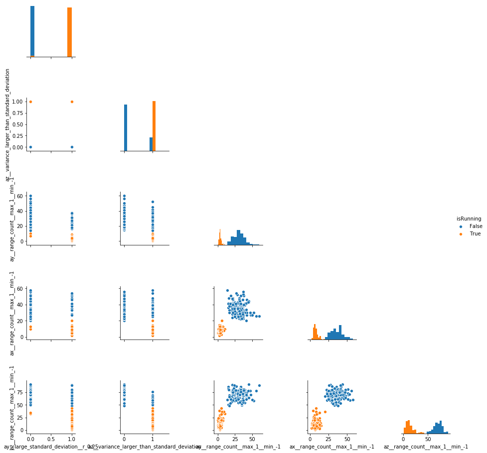

```python
sns.pairplot(feature_matrix,
             hue='isRunning',
             corner=True,
             diag_kind='hist'
            )
```

The individual (diagonal) features tend to be bimodal, except for az**variance_larger_than_standard_deviation. ay**range_count**max_1**min_-1 and ax**range_count**max*1__min*-1 form two linearly seperable clusters.  
Most feature-pairs are entirely seperable.  
It is interesting that some of the walking data had az_variance_greater_than_standard_deviation == 1 (2nd diagonal plot)

```python
# Apparently feature scaling is not required for Random Forests -
# https://stackoverflow.com/questions/8961586/do-i-need-to-normalize-or-scale-data-for-randomforest-r-package
from sklearn.ensemble import RandomForestClassifier

clf = RandomForestClassifier(max_features=5)
clf.fit(X[select.relevant_features], y)
```

```
RandomForestClassifier(bootstrap=True, ccp_alpha=0.0, class_weight=None,
                       criterion='gini', max_depth=None, max_features=5,
                       max_leaf_nodes=None, max_samples=None,
                       min_impurity_decrease=0.0, min_impurity_split=None,
                       min_samples_leaf=1, min_samples_split=2,
                       min_weight_fraction_leaf=0.0, n_estimators=100,
                       n_jobs=None, oob_score=False, random_state=None,
                       verbose=0, warm_start=False)
```

```python
from sklearn.pipeline import make_pipeline

model = make_pipeline(FeatureSelector(), RandomForestClassifier())
```

```python
X.shape
```

```
(266, 2252)
```

```python
from sklearn.model_selection import RepeatedKFold

kf = RepeatedKFold(n_splits=10, n_repeats=10)

predictions = list()
truth = list()
for train, test in kf.split(X):
    model.fit(X.iloc[train], y.iloc[train])
    predictions.append(model.predict_proba(X.iloc[test]))
    truth.append(y.iloc[test])
```

```python
p = np.concatenate(predictions)
t = np.concatenate(truth)
p, t
```

```
(array([[0.02, 0.98],
        [0.  , 1.  ],
        [0.  , 1.  ],
        ...,
        [1.  , 0.  ],
        [1.  , 0.  ],
        [1.  , 0.  ]]),
 array([ True,  True,  True, ..., False, False, False]))
```

```python
# As shown above, truths correspond with the 2nd column of predictions.
# The predictions are also quite confident, likely due to the ease of separtion between classes for the features
from sklearn.metrics import roc_curve

fpr, tpr, thresholds = roc_curve(t, p[:,1])
```

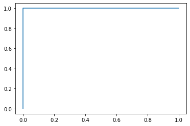

```python
plt.plot(fpr, tpr)
```

```python
from sklearn.metrics import roc_auc_score

roc_auc_score(t, p[:,1])
```

```
1.0
```

It's likely this score would decrease given more data, or if the data collected was more varied (e.g. changing to shorter/ longer strides for running and walking)